# Current Architecture

The current architecture of the Kernel-Nuller component is shown in the following figure:

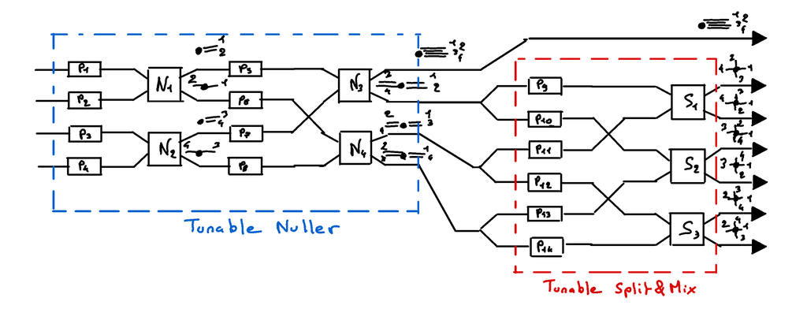

From left to right, we have the following components:

- $P_n$ are the delayers, they use an electrical power $p_n$ to warm up the fiber core and induce a phase shift $\phi_{n,\lambda} = f_\lambda(p_n)$ on the input signal.
- $N_n$ are the Nulling 2x2 MMI. They make constructive interference on the first output channel and oppose the phase to make destructive interference on the second output channel.
- $S_n$ are the Split&Mix 2x2 MMI. As this system is insensitive to the global phase, we can consider that these system simply dephase one of the input by $\theta = \pi/2$ on an output channel and by $-\theta$ on the other one.

Null depths can then be computed on each of the Split&Mix output channels compared to the bright one on top of the scheme.

# Perturbation sources

There is several perturbation sources that can affect the system. On this architecture, we only consider the phase perturbations. There is 2 mains sources of perturbations:

- Atmospheric perturbations (red) that are not correlated between the different channels and that are evolving in a milisecond time frame.
- System perturbation (blue) that are here simplified as MMI defects but actually also include the fiber lenght incertainty and the phase shifters errors. These perturbations are correlated between different channels and seems to be constant.

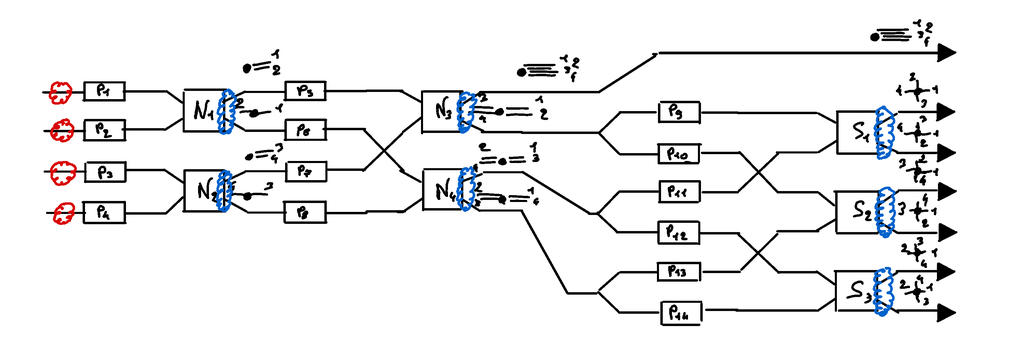

# Possible DoF reduction

As the MMI are insensitive to the global phase of the inputs, we can reduce the degrees of freedom by considering the phase of one of the MMI input channel as the reference. Thus, we don't need to tune the phase associated to this reference channel, so we simply fix the parameter to a given value. As this architecture work with 2x2 MMI, it imply in this architecture that we can reduce the number of degree of freedom by a factor 2.

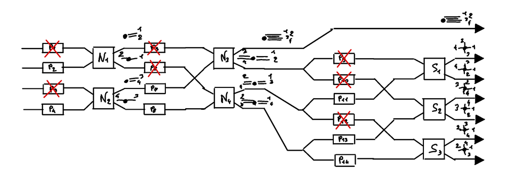

From this graph, we can deduce the phase shifters that will influencate each output:

- Bright output: $P_2$, $P_4$ and $P_7$
- Dark output 1 & 2 : $2\times P_2$, $2\times P_4$, $P_7$, $P_8$ and $P_{11}$
- Dark output 3 & 4 : $2\times P_2$, $2\times P_4$, $P_7$, $P_8$ and $P_{13}$
- Dark output 5 & 6 : $2\times P_2$, $2\times P_4$, $P_8$ and $P_{14}$

We see that $P_2$, $P_4$ and $P_7$ and $P_8$ impact all (or most of) the outputs so they are strongly correlated. They are thus the ones that will probably be the most challenging to tune.

# Milestone 1 : Analytical model

This first milestone consist of expressing the matrix associated to each component and deduce it's overall transfer function by ensuring it is physically relevant (must be energy conservative, so respect the relation $U^* U = I$)

> This step was made with the 4x4 MMI architecture so I have to redo it for this 2x2 MMI architecture.

# Milestone 2 : Numerical model

This second milestone consist of implementing this later transfer function in a numerical model and test it with and without star companion and with different levels of perturbations. The second objective in this milestone is to make a simple code that find the perfect phase shifters configuration to reach the deepest nulling depth.

> This milestone was also made with the 4x4 MMI architecture, I can easily adapt the code for the new one. However, I made a mistake in the previous numerical model consisting of summing the complex amplitude of the star and the planet which are not coherent. This correction imply to rewrite a bigger part of the code to make it indepently for the star and for the companion.

# Milestone 3 : Supervised AI training

At this point I will be able to generate a dataset using different inputs and different perturbations on which I will be able to train an AI finding the best phase shifters configuration.

This AI will firstly take in input :

- The current phase shifters configuration
- The output complex amplitudes
- The input complexe amplitudes

In a second step, I will remove the input amplitudes, and then in a third step, give to the AI only the output intensities. If this last step doesn't work because of the lack of information, I plan to add to it the input intensities.

# Milstone 4 : Unsupervised AI training

Except if the results of the milestone 3 are really satisfying, I think it could be interesting to compare the supervised method with the unsupervised one by computing a score associated to the null depth and other science information we want to get. This unsupervised method will not be limited by a dataset and all it's inherent limitations.

# Milestone 5 : Test on the lab

Once one (or both) of the previous method gives satisfying results, I plan to test it in the lab to see how it behave in a more realistic conditions.

For the supervised method, there is a possibility to exploti a model that wwas previously trained on the numerical model and train it again on the lab data. This pre-training method is often used to reduce the amount of needed "real" data to train the model by using the numerical data to give a first intuition to the model. However, if the dataset generation is a fast process, we can still consider to train the model directly on the lab data and compare both results to see if the pre-training method is worth it or not in this highly sensitive system.